# ElvisRamirezFA_Assignment1_FinalVersion

#### Assignment #1

#### Elvis Ramirez - Student ID: 4354150

#### Business Analytics, St Lawrence College - Kingston

#### ADMN5006 Financial Analytics

# Import the required libraries

```python
import numpy as np
import os
import pandas as pd
import matplotlib.pyplot as plt
import seaborn as sns
from sklearn.ensemble import RandomForestRegressor
from sklearn.model_selection import train_test_split
from sklearn.metrics import mean_squared_error, mean_absolute_error
from sklearn.model_selection import train_test_split
from sklearn.ensemble import RandomForestClassifier
from sklearn.metrics import classification_report
from sklearn.metrics import classification_report, confusion_matrix, accuracy_score, f1_score, recall_score, precision_score
from sklearn.preprocessing import StandardScaler
from imblearn.over_sampling import SMOTE
from sklearn.linear_model import LogisticRegression
from sklearn.tree import DecisionTreeClassifier
```

# Import the required data

```python
myBankrupDF = pd.read_excel('C:/datasets2/Bankruptcy_data.xlsx', sheet_name='Sheet1')
```

# Exploraty Data Analysis (EDA)

```python
myBankrupDF
```

|  | EPS | Liquidity | Profitability | Productivity | Leverage Ratio | Asset Turnover | Operational Margin | Return on Equity | Market Book Ratio | Assets Growth | Sales Growth | Employee Growth | BK |
| --- | --- | --- | --- | --- | --- | --- | --- | --- | --- | --- | --- | --- | --- |
| 0 | 1.580000 | 0.360000 | 0.180000 | 0.130000 | 1.330000 | 1.770000 | 0.070000 | 0.150000 | 2.220000 | NaN | NaN | NaN | 0 |
| 1 | 1.410000 | 0.360000 | 0.190000 | 0.120000 | 1.310000 | 1.590000 | 0.070000 | 0.130000 | 2.410000 | 0.126319 | 0.014278 | 0.040179 | 0 |
| 2 | 0.310000 | 0.320000 | 0.130000 | 0.080000 | 1.030000 | 1.550000 | 0.050000 | 0.040000 | 2.560000 | 0.368077 | 0.327909 | 0.566524 | 0 |
| 3 | 0.710000 | 0.280000 | 0.140000 | 0.080000 | 0.800000 | 1.390000 | 0.060000 | 0.050000 | 5.280000 | -0.020809 | -0.118904 | -0.095890 | 0 |
| 4 | 0.750000 | 0.410000 | 0.130000 | 0.080000 | 0.200000 | 1.300000 | 0.060000 | 0.040000 | 8.680000 | 0.233089 | 0.146807 | 0.053030 | 0 |
| ... | ... | ... | ... | ... | ... | ... | ... | ... | ... | ... | ... | ... | ... |
| 92867 | -1.488171 | -0.015494 | -0.758859 | -0.056905 | -1042.104918 | 0.174115 | -0.326823 | -6.614095 | -1.846719 | -0.073287 | -0.557483 | -0.076923 | 0 |
| 92868 | -1.807630 | 0.093838 | -1.204734 | -0.121122 | -4.530214 | 0.215844 | -0.561155 | -4.519074 | -2.474549 | -0.201835 | -0.010544 | -0.208333 | 0 |
| 92869 | -0.015660 | 0.039260 | 0.000000 | -0.082429 | 0.744907 | 0.254186 | -0.324286 | -0.569448 | 3274.505633 | -0.168001 | -0.020206 | -0.105263 | 0 |
| 92870 | -0.133054 | 0.053678 | -0.029471 | 0.000998 | 0.574570 | 0.195683 | 0.005101 | -0.085842 | 36.474842 | 0.076936 | -0.170928 | -0.058824 | 0 |
| 92871 | -0.648028 | -0.036524 | -0.219774 | -0.144842 | 0.693342 | 0.222476 | -0.651048 | -0.498483 | 55.624410 | -0.063630 | 0.064574 | 0.062500 | 1 |

92872 rows × 13 columns

```python
# Head dataset
print(myBankrupDF.head())
```

```
    EPS  Liquidity  Profitability  Productivity  Leverage Ratio  \
0  1.58       0.36           0.18          0.13            1.33
1  1.41       0.36           0.19          0.12            1.31
2  0.31       0.32           0.13          0.08            1.03
3  0.71       0.28           0.14          0.08            0.80
4  0.75       0.41           0.13          0.08            0.20

   Asset Turnover  Operational Margin  Return on Equity  Market Book Ratio  \
0            1.77                0.07              0.15               2.22
1            1.59                0.07              0.13               2.41
2            1.55                0.05              0.04               2.56
3            1.39                0.06              0.05               5.28
4            1.30                0.06              0.04               8.68

   Assets Growth  Sales Growth  Employee Growth  BK
0            NaN           NaN              NaN   0
1       0.126319      0.014278         0.040179   0
2       0.368077      0.327909         0.566524   0
3      -0.020809     -0.118904        -0.095890   0
4       0.233089      0.146807         0.053030   0
```

```python
# Info about columns and datatypes
print(myBankrupDF.info())
```

```
<class 'pandas.core.frame.DataFrame'>
RangeIndex: 92872 entries, 0 to 92871
Data columns (total 13 columns):
 #   Column              Non-Null Count  Dtype
---  ------              --------------  -----
 0   EPS                 92867 non-null  float64
 1   Liquidity           92625 non-null  float64
 2   Profitability       92625 non-null  float64
 3   Productivity        92625 non-null  float64
 4   Leverage Ratio      92846 non-null  float64
 5   Asset Turnover      92625 non-null  float64
 6   Operational Margin  87315 non-null  float64
 7   Return on Equity    92864 non-null  float64
 8   Market Book Ratio   92815 non-null  float64
 9   Assets Growth       86171 non-null  float64
 10  Sales Growth        86171 non-null  float64
 11  Employee Growth     85862 non-null  float64
 12  BK                  92872 non-null  int64
dtypes: float64(12), int64(1)
memory usage: 9.2 MB
None
```

```python
# Descriptive stats
print(myBankrupDF.describe())
```

```
                 EPS     Liquidity  Profitability  Productivity  \
count   92867.000000  92625.000000   92625.000000  92625.000000
mean      -14.461355     -2.631237     -29.537274     -1.222870
std      2195.467288    121.610921     677.230667     35.885556
min   -384000.000000 -25968.520000  -79682.000000  -5093.000000
25%        -0.140000      0.020000      -0.640000     -0.060000
50%         0.330000      0.190000       0.070000      0.060000
75%         1.530000      0.400000       0.310000      0.110000
max     55339.000000      1.000000     140.580000   1102.000000

       Leverage Ratio  Asset Turnover  Operational Margin  Return on Equity  \
count    92846.000000    92625.000000        87315.000000      92864.000000
mean         1.345316        1.053613           -7.915485         -2.112382
std        253.038093        2.115945          214.460079        352.596902
min      -7811.000000      -31.590000       -30175.700000     -88875.140000
25%          0.000000        0.390000           -0.030000         -0.080000
50%          0.280000        0.830000            0.060000          0.030000
75%          0.820000        1.390000            0.140000          0.070000
max      75970.380000      276.380000          394.470000      39500.000000

       Market Book Ratio  Assets Growth  Sales Growth  Employee Growth  \
count       9.281500e+04   86171.000000  86171.000000     85862.000000
mean        3.585063e+02       1.294075      1.900108         0.343322
std         2.606364e+04      73.769522    177.632638        14.074156
min        -3.151500e+06      -1.000000    -27.431034        -1.000000
25%         1.120000e+01      -0.052596     -0.033522        -0.048107
50%         5.828000e+01       0.051844      0.059733         0.017241
75%         2.401400e+02       0.192062      0.204231         0.130944
max         3.455419e+06   14231.000000  39850.000000      2699.000000

                 BK
count  92872.000000
mean       0.006008
std        0.077280
min        0.000000
25%        0.000000
50%        0.000000
75%        0.000000
max        1.000000
```

```python
# Check the prediction variable distribution
print(myBankrupDF['BK'].value_counts())
```

```
0    92314
1      558
Name: BK, dtype: int64
```

# imbalance in the dataset.

#### According to prediction variable distribution, the dataset it's inbalance, it's important to validate different techniques for avoid to lose important data that will be use for the ML model to training and test in order to get the best prediction for future values of bankrupt

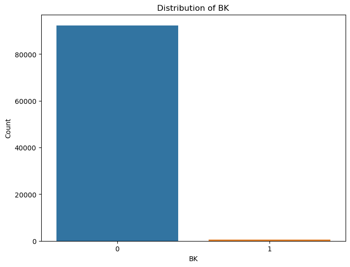

```python
# Bar plot of categorical feature (BK) counts
plt.figure(figsize=(8, 6))
sns.countplot(data=myBankrupDF, x='BK')
plt.xlabel('BK')
plt.ylabel('Count')
plt.title('Distribution of BK')
plt.show()
```

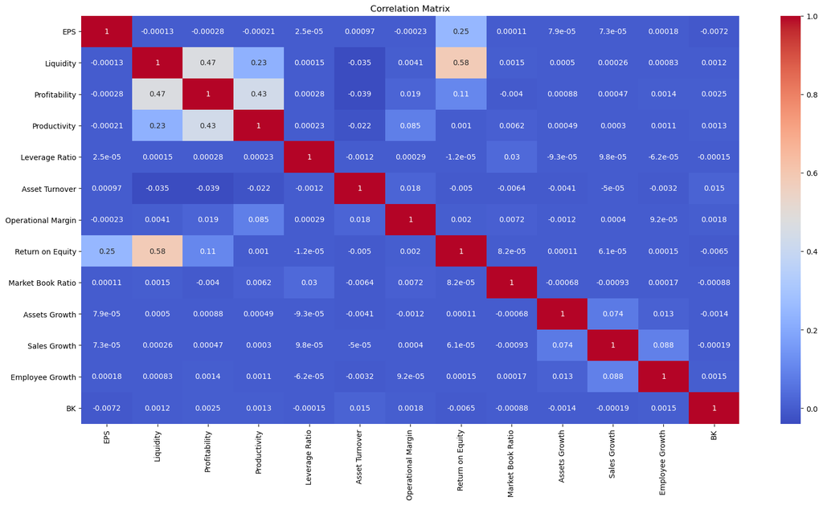

```python
#Correlation matrix
myBrDF_corrMatrix = myBankrupDF.corr()
plt.figure(figsize=(20, 10))
sns.heatmap(myBrDF_corrMatrix, annot=True, cmap="coolwarm")
plt.title("Correlation Matrix")
plt.show()
```

### Create and analyze box plots for each numeric feature grouped by BK

```python
##### Specify the columns
feautures_columns = ['EPS', 'Liquidity', 'Profitability', 'Productivity', 'Leverage Ratio', 'Asset Turnover',
           'Operational Margin', 'Return on Equity', 'Market Book Ratio', 'Assets Growth',
           'Sales Growth', 'Employee Growth']
```

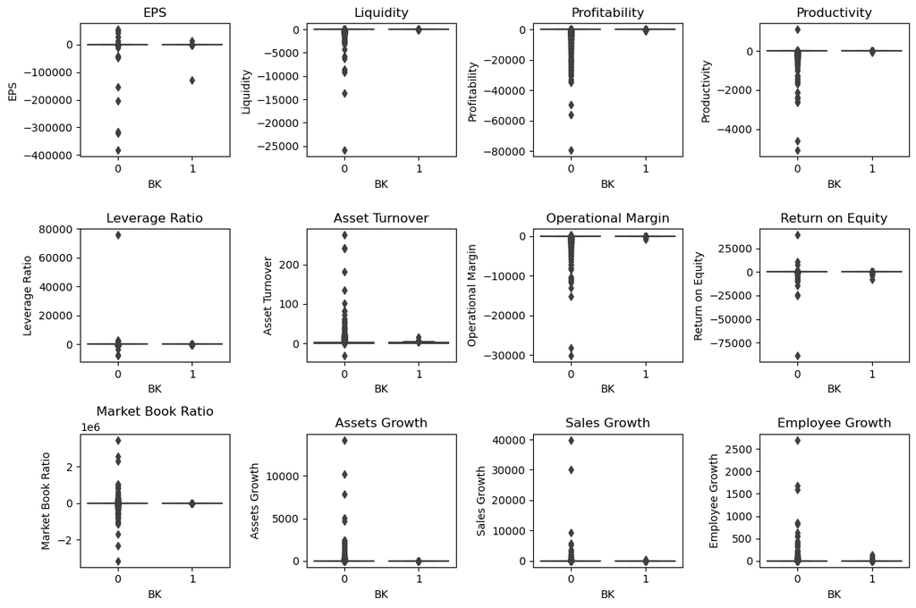

```python
# Set the figure size
plt.figure(figsize=(12, 8))


for feature in feautures_columns:
    plt.subplot(3, 4, feautures_columns.index(feature) + 1)
    sns.boxplot(x='BK', y=feature, data=myBankrupDF)
    plt.title(feature)

# Adjust the spacing between subplots
plt.tight_layout()

# Display the plots
plt.show()
```

### Create and analyze box plots for each numeric feature without grouping

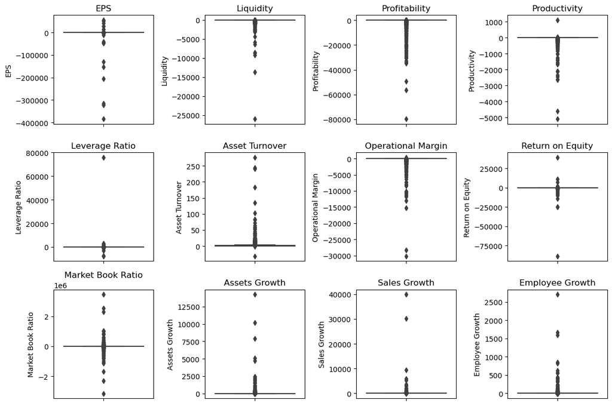

```python
# Set the figure size
plt.figure(figsize=(12, 8))

# Create box plots for each numeric feature
for feature in feautures_columns:
    plt.subplot(3, 4, feautures_columns.index(feature) + 1)
    sns.boxplot(y=feature, data=myBankrupDF)
    plt.title(feature)

# Adjust the spacing between subplots
plt.tight_layout()

# Display the plots
plt.show()
```

# Data Processing

```python
# Check for missing values
print(myBankrupDF.isnull().sum())
```

```
EPS                      5
Liquidity              247
Profitability          247
Productivity           247
Leverage Ratio          26
Asset Turnover         247
Operational Margin    5557
Return on Equity         8
Market Book Ratio       57
Assets Growth         6701
Sales Growth          6701
Employee Growth       7010
BK                       0
dtype: int64
```

### Impute missing values using median strategy

```python
from sklearn.impute import SimpleImputer
from sklearn.preprocessing import StandardScaler
```

```python
# Impute missing values using median strategy
imputer = SimpleImputer(strategy='median')
myImputed_BrDF = pd.DataFrame()
myImputed_BrDF[['EPS', 'Liquidity', 'Profitability', 'Productivity', 'Leverage Ratio', 'Asset Turnover',
           'Operational Margin', 'Return on Equity', 'Market Book Ratio', 'Assets Growth',
           'Sales Growth', 'Employee Growth','BK']] = imputer.fit_transform(myBankrupDF[['EPS', 'Liquidity', 'Profitability', 'Productivity', 'Leverage Ratio', 'Asset Turnover',
           'Operational Margin', 'Return on Equity', 'Market Book Ratio', 'Assets Growth',
           'Sales Growth', 'Employee Growth','BK']])
```

```python
# Check for missing values after to impute mean
print(myImputed_BrDF.isnull().sum())
```

```
EPS                   0
Liquidity             0
Profitability         0
Productivity          0
Leverage Ratio        0
Asset Turnover        0
Operational Margin    0
Return on Equity      0
Market Book Ratio     0
Assets Growth         0
Sales Growth          0
Employee Growth       0
BK                    0
dtype: int64
```

# Evaluation to remove or not Outliers using Z-Score

```python
# Calculate z-scores for each column
z_scores = np.abs((myImputed_BrDF - myImputed_BrDF.mean()) / myImputed_BrDF.std())

# Set a threshold for z-scores
threshold = 3

# Exclude outliers based on the threshold
myImputedDF_excluded_Zscore = myImputed_BrDF[(z_scores <= threshold).all(axis=1)]

# Display the resulting DataFrame
print(myImputedDF_excluded_Zscore)
```

```
            EPS  Liquidity  Profitability  Productivity  Leverage Ratio  \
0      1.580000   0.360000       0.180000      0.130000        1.330000
1      1.410000   0.360000       0.190000      0.120000        1.310000
2      0.310000   0.320000       0.130000      0.080000        1.030000
3      0.710000   0.280000       0.140000      0.080000        0.800000
4      0.750000   0.410000       0.130000      0.080000        0.200000
...         ...        ...            ...           ...             ...
92865 -0.358336  -0.064598      -0.139986     -0.012580        1.548588
92866 -1.468547  -0.013103      -0.565395     -0.245705        5.768961
92868 -1.807630   0.093838      -1.204734     -0.121122       -4.530214
92869 -0.015660   0.039260       0.000000     -0.082429        0.744907
92870 -0.133054   0.053678      -0.029471      0.000998        0.574570

       Asset Turnover  Operational Margin  Return on Equity  \
0            1.770000            0.070000          0.150000
```

[output cut: 25 more lines]

```python
myImputedDF_excluded_Zscore.shape
```

```
(91231, 13)
```

```python
# Check the prediction variable distribution after remove outliers using Z-score technique
print(myImputedDF_excluded_Zscore['BK'].value_counts())
```

```
0.0    91231
Name: BK, dtype: int64
```

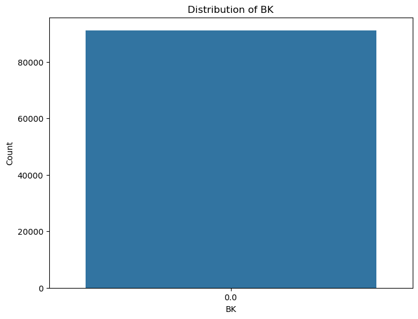

```python
# Bar plot of categorical feature (BK) counts after to remove outliers using Z-Score
plt.figure(figsize=(8, 6))
sns.countplot(data=myImputedDF_excluded_Zscore, x='BK')
plt.xlabel('BK')
plt.ylabel('Count')
plt.title('Distribution of BK')
plt.show()
```

# After removing the outliers from the dataset using Z-score,

#### The BK column representing bankruptcy (minority class) only contains values of 0 (majority class). This can lead to class imbalance in the data, where the dataset has a majority class (0) and no instances of the minority class (1).

# ----------------------------------------

# Evaluation to remove or not Outliers using IRQ

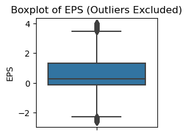

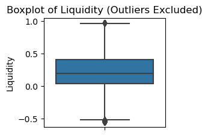

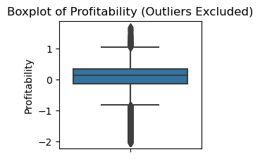

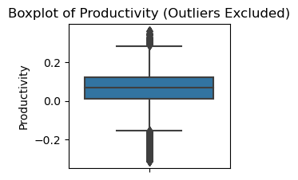

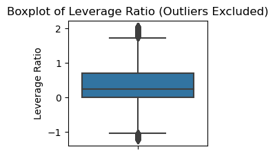

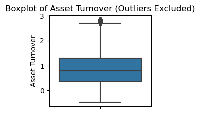

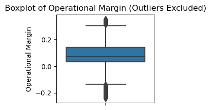

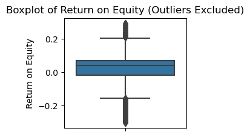

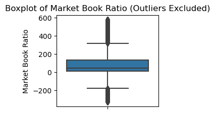

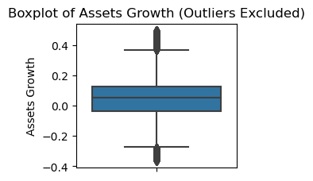

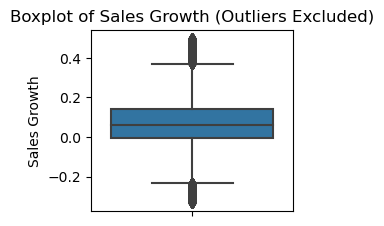

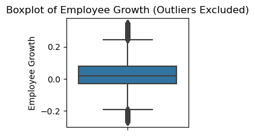

[1 more figures not shown]

```python
##### Specify the columns to exclude outliers
columnsToExcludeOutliers = ['EPS', 'Liquidity', 'Profitability', 'Productivity', 'Leverage Ratio', 'Asset Turnover',
           'Operational Margin', 'Return on Equity', 'Market Book Ratio', 'Assets Growth',
           'Sales Growth', 'Employee Growth','BK']

# Imputed DataFrame after to fill missing values
myImputed_BrDF

# Create an empty DataFrame to store the filtered data
myImputedDF_excluded_IQR = pd.DataFrame()

# Set the figure size
plt.figure(figsize=(12, 8))

# Iterate through each column
for col in columnsToExcludeOutliers:
    # Calculate the IQR for the current column
    Q1 = myImputed_BrDF[col].quantile(0.25)
    Q3 = myImputed_BrDF[col].quantile(0.75)
    IQR = Q3 - Q1

    # Define the outlier boundaries index for the current column
    lower_index = Q1 - (1.5 * IQR)
    upper_index = Q3 + (1.5 * IQR)

    # Filter out the outliers for the current column
    columns_filtered = myImputed_BrDF[(myImputed_BrDF[col] >= lower_index) & (myImputed_BrDF[col] <= upper_index)]


    # Append the filtered column to the data_filtered DataFrame
    myImputedDF_excluded_IQR[col] = columns_filtered[col]



    # Create a boxplot for the current column
    # Set the figure size
    plt.figure(figsize=(12, 8))
    plt.subplot(3, 4, columnsToExcludeOutliers.index(feature) + 1)
    sns.boxplot(y=col, data=columns_filtered)
    plt.title(f'Boxplot of {col} (Outliers Excluded)')
    plt.show()
```

```python
myImputedDF_excluded_IQR.shape
```

```
(84476, 13)
```

```python
# Check the prediction variable distribution after remove outliers using IRQ technique
print(myImputedDF_excluded_IQR['BK'].value_counts())
```

```
0.0    84044
Name: BK, dtype: int64
```

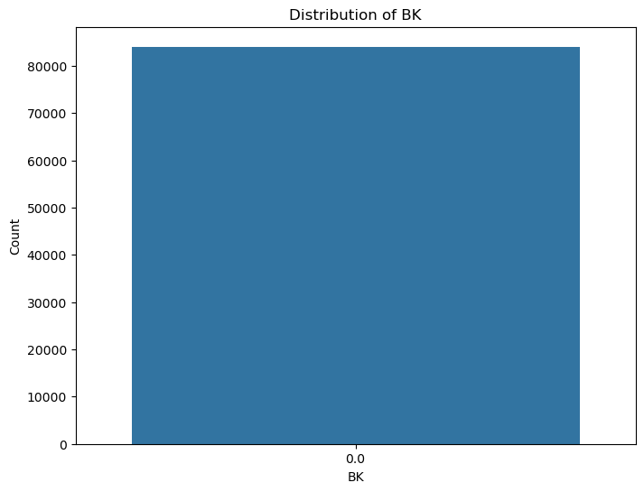

```python
# Bar plot of categorical feature (BK) counts after to remove outliers using IRQ
plt.figure(figsize=(8, 6))
sns.countplot(data=myImputedDF_excluded_IQR, x='BK')
plt.xlabel('BK')
plt.ylabel('Count')
plt.title('Distribution of BK')
plt.show()
```

# After removing the outliers from the dataset using IRQ,

#### The BK column representing bankruptcy (minority class) only contains values of 0 (majority class). This can lead to class imbalance in the data, where the dataset has a majority class (0) and no instances of the minority class (1).

# Conclusion after to validate removing outliers

#### After to validate removing outliers, it results in the loss of all data with a value of 1 in the BK column. It is important to carefully consider the decision to remove outliers. In this case, by losing all the data with a value of 1, the model may not be able to properly learn the patterns associated with the minority class and could result in inaccurate or biased predictions towards the majority class.

## Then I will continue using original dataframe after the imputed missing values including Outliers -> myImputed_BrDF

```python
myImputed_BrDF
```

|  | EPS | Liquidity | Profitability | Productivity | Leverage Ratio | Asset Turnover | Operational Margin | Return on Equity | Market Book Ratio | Assets Growth | Sales Growth | Employee Growth | BK |
| --- | --- | --- | --- | --- | --- | --- | --- | --- | --- | --- | --- | --- | --- |
| 0 | 1.580000 | 0.360000 | 0.180000 | 0.130000 | 1.330000 | 1.770000 | 0.070000 | 0.150000 | 2.220000 | 0.051844 | 0.059733 | 0.017241 | 0.0 |
| 1 | 1.410000 | 0.360000 | 0.190000 | 0.120000 | 1.310000 | 1.590000 | 0.070000 | 0.130000 | 2.410000 | 0.126319 | 0.014278 | 0.040179 | 0.0 |
| 2 | 0.310000 | 0.320000 | 0.130000 | 0.080000 | 1.030000 | 1.550000 | 0.050000 | 0.040000 | 2.560000 | 0.368077 | 0.327909 | 0.566524 | 0.0 |
| 3 | 0.710000 | 0.280000 | 0.140000 | 0.080000 | 0.800000 | 1.390000 | 0.060000 | 0.050000 | 5.280000 | -0.020809 | -0.118904 | -0.095890 | 0.0 |
| 4 | 0.750000 | 0.410000 | 0.130000 | 0.080000 | 0.200000 | 1.300000 | 0.060000 | 0.040000 | 8.680000 | 0.233089 | 0.146807 | 0.053030 | 0.0 |
| ... | ... | ... | ... | ... | ... | ... | ... | ... | ... | ... | ... | ... | ... |
| 92867 | -1.488171 | -0.015494 | -0.758859 | -0.056905 | -1042.104918 | 0.174115 | -0.326823 | -6.614095 | -1.846719 | -0.073287 | -0.557483 | -0.076923 | 0.0 |
| 92868 | -1.807630 | 0.093838 | -1.204734 | -0.121122 | -4.530214 | 0.215844 | -0.561155 | -4.519074 | -2.474549 | -0.201835 | -0.010544 | -0.208333 | 0.0 |
| 92869 | -0.015660 | 0.039260 | 0.000000 | -0.082429 | 0.744907 | 0.254186 | -0.324286 | -0.569448 | 3274.505633 | -0.168001 | -0.020206 | -0.105263 | 0.0 |
| 92870 | -0.133054 | 0.053678 | -0.029471 | 0.000998 | 0.574570 | 0.195683 | 0.005101 | -0.085842 | 36.474842 | 0.076936 | -0.170928 | -0.058824 | 0.0 |
| 92871 | -0.648028 | -0.036524 | -0.219774 | -0.144842 | 0.693342 | 0.222476 | -0.651048 | -0.498483 | 55.624410 | -0.063630 | 0.064574 | 0.062500 | 1.0 |

92872 rows × 13 columns

```python
myImputed_BrDF.shape
```

```
(92872, 13)
```

# Step 5 - Model Developement

```python
# Split the input variables (X) and predictor variable (y)
X = myImputed_BrDF.drop("BK", axis=1)
y = myImputed_BrDF["BK"]
```

```python
X
```

|  | EPS | Liquidity | Profitability | Productivity | Leverage Ratio | Asset Turnover | Operational Margin | Return on Equity | Market Book Ratio | Assets Growth | Sales Growth | Employee Growth |
| --- | --- | --- | --- | --- | --- | --- | --- | --- | --- | --- | --- | --- |
| 0 | 1.580000 | 0.360000 | 0.180000 | 0.130000 | 1.330000 | 1.770000 | 0.070000 | 0.150000 | 2.220000 | 0.051844 | 0.059733 | 0.017241 |
| 1 | 1.410000 | 0.360000 | 0.190000 | 0.120000 | 1.310000 | 1.590000 | 0.070000 | 0.130000 | 2.410000 | 0.126319 | 0.014278 | 0.040179 |
| 2 | 0.310000 | 0.320000 | 0.130000 | 0.080000 | 1.030000 | 1.550000 | 0.050000 | 0.040000 | 2.560000 | 0.368077 | 0.327909 | 0.566524 |
| 3 | 0.710000 | 0.280000 | 0.140000 | 0.080000 | 0.800000 | 1.390000 | 0.060000 | 0.050000 | 5.280000 | -0.020809 | -0.118904 | -0.095890 |
| 4 | 0.750000 | 0.410000 | 0.130000 | 0.080000 | 0.200000 | 1.300000 | 0.060000 | 0.040000 | 8.680000 | 0.233089 | 0.146807 | 0.053030 |
| ... | ... | ... | ... | ... | ... | ... | ... | ... | ... | ... | ... | ... |
| 92867 | -1.488171 | -0.015494 | -0.758859 | -0.056905 | -1042.104918 | 0.174115 | -0.326823 | -6.614095 | -1.846719 | -0.073287 | -0.557483 | -0.076923 |
| 92868 | -1.807630 | 0.093838 | -1.204734 | -0.121122 | -4.530214 | 0.215844 | -0.561155 | -4.519074 | -2.474549 | -0.201835 | -0.010544 | -0.208333 |
| 92869 | -0.015660 | 0.039260 | 0.000000 | -0.082429 | 0.744907 | 0.254186 | -0.324286 | -0.569448 | 3274.505633 | -0.168001 | -0.020206 | -0.105263 |
| 92870 | -0.133054 | 0.053678 | -0.029471 | 0.000998 | 0.574570 | 0.195683 | 0.005101 | -0.085842 | 36.474842 | 0.076936 | -0.170928 | -0.058824 |
| 92871 | -0.648028 | -0.036524 | -0.219774 | -0.144842 | 0.693342 | 0.222476 | -0.651048 | -0.498483 | 55.624410 | -0.063630 | 0.064574 | 0.062500 |

92872 rows × 12 columns

```python
y
```

```
0        0.0
1        0.0
2        0.0
3        0.0
4        0.0
        ...
92867    0.0
92868    0.0
92869    0.0
92870    0.0
92871    1.0
Name: BK, Length: 92872, dtype: float64
```

```python
# Split the dataset into training and testing sets
X_train, X_test, y_train, y_test = train_test_split(X, y, test_size=0.2, random_state=42)
```

```python
# Model Selection
# Create instance for the models to evaluate
logistic_model = LogisticRegression()
random_forest_model = RandomForestClassifier()
decision_tree_model = DecisionTreeClassifier()
```

```python
# 3.2 Model Development process
# Create a dictionary for save the resulf of ML models
model_results = {}
```

```python
# Apply SMOTE of training dataset
smote = SMOTE(random_state=42)
X_train_resampled, y_train_resampled = smote.fit_resample(X_train, y_train)
```

```python
# Standarization of input variables
scaler = StandardScaler()
X_train_resampled = scaler.fit_transform(X_train_resampled)
X_test = scaler.transform(X_test)
```

# training and evaluated Logistic regretion model

```python
logistic_model.fit(X_train_resampled, y_train_resampled)
y_pred_logistic = logistic_model.predict(X_test)
logistic_accuracy = accuracy_score(y_test, y_pred_logistic)
logistic_precision = precision_score(y_test, y_pred_logistic)
logistic_recall = recall_score(y_test, y_pred_logistic)
logistic_f1 = f1_score(y_test, y_pred_logistic)
logistic_confusion = confusion_matrix(y_test, y_pred_logistic)
```

# training and evaluated Random Forest

```python
random_forest_model.fit(X_train_resampled, y_train_resampled)
y_pred_rf = random_forest_model.predict(X_test)
rf_accuracy = accuracy_score(y_test, y_pred_rf)
rf_precision = precision_score(y_test, y_pred_rf)
rf_recall = recall_score(y_test, y_pred_rf)
rf_f1 = f1_score(y_test, y_pred_rf)
rf_confusion = confusion_matrix(y_test, y_pred_rf)
```

# training and evaluated Logistic Desicion Tree

```python
decision_tree_model.fit(X_train_resampled, y_train_resampled)
y_pred_dt = decision_tree_model.predict(X_test)
dt_accuracy = accuracy_score(y_test, y_pred_dt)
dt_precision = precision_score(y_test, y_pred_dt)
dt_recall = recall_score(y_test, y_pred_dt)
dt_f1 = f1_score(y_test, y_pred_dt)
dt_confusion = confusion_matrix(y_test, y_pred_dt)
```

```python
#Save the results of ML models into Dictionary
model_results["Logistic Regression"] = {"Accuracy": logistic_accuracy, "Precision": logistic_precision,
                                        "Recall": logistic_recall, "F1-score": logistic_f1,
                                        "Confusion Matrix": logistic_confusion}
model_results["Random Forest"] = {"Accuracy": rf_accuracy, "Precision": rf_precision,
                                  "Recall": rf_recall, "F1-score": rf_f1,
                                 "Confusion Matrix": rf_confusion}
model_results["Decision Tree"] = {"Accuracy": dt_accuracy, "Precision": dt_precision,
                                  "Recall": dt_recall, "F1-score": dt_f1,
                                 "Confusion Matrix": dt_confusion}
```

```python
#Print the results of the models
for model_name, results in model_results.items():
    print(model_name)
    print("Accuracy:", results["Accuracy"])
    print("Precision:", results["Precision"])
    print("Recall:", results["Recall"])
    print("F1-score:", results["F1-score"])
    print("Confusion Matrix:", results["Confusion Matrix"])
    print()
```

```
Logistic Regression
Accuracy: 0.6930820995962315
Precision: 0.010341805433829974
Recall: 0.5175438596491229
F1-score: 0.020278398350232
Confusion Matrix: [[12815  5646]
 [   55    59]]

Random Forest
Accuracy: 0.9828802153432032
Precision: 0.11363636363636363
Recall: 0.2631578947368421
F1-score: 0.15873015873015872
Confusion Matrix: [[18227   234]
 [   84    30]]

Decision Tree
Accuracy: 0.9666756393001346
Precision: 0.06086956521739131
Recall: 0.30701754385964913
F1-score: 0.10159651669085633
Confusion Matrix: [[17921   540]
 [   79    35]]
```